# Vectors - Data Frames - Tibbles

Mike LeVan

Let’s talk a little bit about structures we can use to store data. These can be complex, so we will just talk about some basic ways in which we will be using them.

## Vectors

A vector is a 1-dimensional (row) structure that can hold multiple elements. For example, we can create a vector that contains 10 numbers such as this one :

[figure not shown]

This example is a 1-dimensional vector that holds 10 values. You can see the **values** that we have saved are 10, 20, 30, 40, 50, 60, 70, 80, 90, and 100. The **index** tells us what position each value is in. The first value is at index 1, the second value is at index 2, and so on.

When creating a new vector, you want to make sure you are giving it a name that makes sense. For example, if you are creating a vector that holds the scores from a test, you might want to name it `test_scores`. This will help you remember what the vector is for when you are working with it later.

In order to create a vector, we can use the `c()` function. This function stands for “combine” and is used to combine multiple values into a single vector. For example, if we wanted to create a vector that holds the numbers from above, we could do it like this:

```r
test_scores <- c(10, 20, 30, 40, 50, 60, 70, 80, 90, 100)

class(test_scores)
```

```
## [1] "numeric"
```

Note : I used the `class()` function to check the type of the object. The output of this command is `numeric`. This tells us that the object is a numeric vector. This is because all of the values in the vector are numbers.

We can access the values by using the index. For example, if we wanted to access the first value in the vector, we could do it like this: `test_scores[1]`. This would return the value `10`.

```r
test_scores[1]
```

```
## [1] 10
```

If I wanted to examine the 4th - 7th entries, I could do it like this: `test_scores[4:7]`. This would return the values `40, 50, 60, 70`.

```r
test_scores[4:7]
```

```
## [1] 40 50 60 70
```

Note that we can’t just pick random locations in the vector. For example, if I wanted to print out the values in the 2nd, 5th, and 9th locations? The command `test_scores[2, 5, 9]` would not work. You would get an error message that stops your script.

Instead, we could create a **vector** that holds the locations we want to examine. For example, we could create a vector that holds the values `2, 5, 9` and use this vector in our command :

```r
test_scores[c(2, 5, 9)]
```

```
## [1] 20 50 90
```

You can also create a vector that holds **text** values. For example, you could create a vector that holds the names of the students in a class. This would look something like this:

```r
student_names <- c("Alice", "Bob", "Charlie", "David", "Eve", "Frank", "Grace", "Hannah", "Ivy", "Jack")

class(student_names)
```

```
## [1] "character"
```

Notice that this vector is of type `character`. This is because all of the values in the vector are text values. You can access the values in the same way as you would with a numeric vector. For example, if you wanted to access the first value in the vector, you could do it like this: `student_names[1]`.

```r
student_names[1]
```

```
## [1] "Alice"
```

We have seen two examples. The first was a vector that contained numeric values and the second was a vector that contained text values. You can also create a vector that contains a mix of both. For example, you could create a vector that contains the names of the students in a class along with their test scores. This would look something like this:

```r
student_data <- c("Alice", 100, "Bob", 90, "Charlie", 80, "David", 70, "Eve", 60, "Frank", 50, "Grace", 40, "Hannah", 30, "Ivy", 20, "Jack", 10)
```

When you create a vector that contains a mix of text and numeric values, you need to be careful.

When you create a vector that contains a mix of text and numeric values, R will convert the text values to a different type. For example, if you have a vector that contains both text and numeric values, the text values will be converted to a type called `character`. This is a type that is used to store text values. For example, if you have a vector that contains the values `10, 20, 30, "Alice", "Bob"`, the text values `"Alice"` and `"Bob"` will be converted to the type `character`. This is because R can’t store text values in a vector that is meant to hold numeric values.

```r
class(student_data)
```

```
## [1] "character"
```

If a vector contains text and numeric values, the text values will be converted to a different type. For example, if you have a vector that contains both text and numeric values, the text values will be converted to a type called `character`. This is a type that is used to store text values. For example, if you have a vector that contains the values `10, 20, 30, "Alice", "Bob"`, the text values `"Alice"` and `"Bob"` will be converted to the type `character`. This is because R can’t store text values in a vector that is meant to hold numeric values.

This can be problematic. For instance, what if we wanted to find the average of the test scores from the `student_data` vector? We would need to convert the text values to numeric values first. We can do this using the `as.numeric()` function. This function converts a vector to a numeric type. For example, if we wanted to convert the `student_data` vector to a numeric type, we could do it like this:

```r
student_data <- as.numeric(student_data)
student_data
```

```
##  [1]  NA 100  NA  90  NA  80  NA  70  NA  60  NA  50  NA  40  NA  30  NA  20  NA
## [20]  10
```

This is interesting because as we see the output, we get `NA` values. This is because the `as.numeric()` function can’t convert text values to numeric values. When it encounters a text value, it returns `NA`. This is a special value that is used to represent missing or undefined values. In this case, it is used to represent the text values that couldn’t be converted to numeric values.

```r
test_scores2 <- student_data[c(2, 4, 6, 8, 10, 12, 14, 16, 18, 20)]
```

Let’s check the vector to make sure it is correct :

```r
test_scores2
```

```
##  [1] 100  90  80  70  60  50  40  30  20  10
```

We can now find the average using the `mean()` function. This function calculates the average of a vector. For example, if we wanted to find the average of the test scores, we could do it like this:

```r
mean(test_scores2)
```

```
## [1] 55
```

The reason why a vector is not useful here is because it is trying to save two different forms of data at once. We are trying to save text and numeric data in the same vector. This is not a good idea. Surely there is an easier way to store the data! That is where data frames come in.

## Data Frames

A data frame is a 2-dimensional (row and column) structure that can hold multiple elements. It is similar to a matrix, but it can hold different types of data in each column. For example, you could create a data frame that holds the names of the students in a class along with their test scores. This would look something like this:

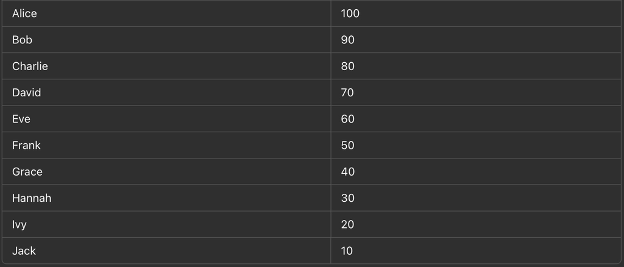

This example is a 2-dimensional data frame that holds 10 rows and 2 columns. This is an example of a **data frame**. In a data frame, each row is called an **observation** and each column is called a **variable**. This data frame has two variables: `name` and `test_score`. The `name` variable holds the names of the students in the class, while the `test_score` variable holds the test scores of the students.

When creating a new data frame, you want to make sure you are giving it a name that makes sense. For example, if you are creating a data frame that holds the names of the students in a class along with their test scores, you might want to name it `student_data`. This will help you remember what the data frame is for when you are working with it later.

In order to create a data frame, we can use the `data.frame()` function. This function is used to create a new data frame. For example, if we wanted to create a data frame that holds the names of the students in a class along with their test scores, we could do it like this:

```r
student_data <- data.frame(
  name = c("Alice", "Bob", "Charlie", "David", "Eve", "Frank", "Grace", "Hannah", "Ivy", "Jack"),
  test_score = c(100, 90, 80, 70, 60, 50, 40, 30, 20, 10)
)

class(student_data)
```

```
## [1] "data.frame"
```

In this example, we are creating a data one column at a time. Since we named these columns as `name` and `test_score`, we can access the values in the same way as we would with a vector. For example, if we wanted to access the first value in the `name` column, we could do it like this: `student_data$name[1]`. This would return the value `Alice`.

```r
student_data$name[1]
```

```
## [1] "Alice"
```

Similarly, if we wanted to access the first value in the `test_score` column, we could do it like this: `student_data$test_score[1]`. This would return the value `100`.

```r
student_data$test_score[1]
```

```
## [1] 100
```

We could also the value in the fifth row and second column like this:

```r
student_data[5, 2]
```

```
## [1] 60
```

If we wanted to print out the entire first column, we could do it like this:

```r
student_data$name
```

```
##  [1] "Alice"   "Bob"     "Charlie" "David"   "Eve"     "Frank"   "Grace"
##  [8] "Hannah"  "Ivy"     "Jack"
```

If we wanted to print out the entire second column, we could do it like this:

```r
student_data$test_score
```

```
##  [1] 100  90  80  70  60  50  40  30  20  10
```

What happens if we wanted to print out the entore data frame? We could do it like this:

```r
student_data
```

```
##       name test_score
## 1    Alice        100
## 2      Bob         90
## 3  Charlie         80
## 4    David         70
## 5      Eve         60
## 6    Frank         50
## 7    Grace         40
## 8   Hannah         30
## 9      Ivy         20
## 10    Jack         10
```

These commands are nice, but if you have a large data set then just printing it off can be a bit overwhelming. We can use the `head()` function to print out the first few rows of the data frame. For example, if we wanted to print out the first 3 rows of the data frame, we could do it like this:

```r
head(student_data, 3)
```

```
##      name test_score
## 1   Alice        100
## 2     Bob         90
## 3 Charlie         80
```

If we wanted to print out the last few rows of the data frame, we could use the `tail()` function. For example, if we wanted to print out the last 5 rows

```r
tail(student_data, 5)
```

```
##      name test_score
## 6   Frank         50
## 7   Grace         40
## 8  Hannah         30
## 9     Ivy         20
## 10   Jack         10
```

The default amount of lines for `head()` and `tail()` is 6. If you don’t specify an amount of lines, it will print out 6 lines.

```r
head(student_data)
```

```
##      name test_score
## 1   Alice        100
## 2     Bob         90
## 3 Charlie         80
## 4   David         70
## 5     Eve         60
## 6   Frank         50
```

How is a data frame different from a tibble? Let’s talk about that next.

## Tibbles

A tibble is a modern version of a data frame that is part of the **tidyverse**. It is similar to a data frame, but it has some additional features that make it easier to work with. For example, tibbles have a nicer print method that makes it easier to view the data. They also have some additional functions that make it easier to manipulate the data. For example, you can use the `select()` function to select specific columns from a tibble. You can also use the `filter()` function to filter rows based on a condition. These functions make it easier to work with tibbles than with data frames.

In order to create a tibble, we can use the `tibble()` function. This function is used to create a new tibble. For example, if we wanted to create a tibble that holds the names of the students in a class along with their test scores, we could do it like this:

```r
# Make sure tidyverse is installed and loaded up. Remember, if you
# need to install it, use the following :

# install.packages(tidyverse)
```

```r
# If it is already downloaded, then you just need to load up the library :

library(tidyverse)
# I have already installed the tibble package, so I will just load it up

library(tibble)

student_data2 <- tibble(
  name = c("Alice", "Bob", "Charlie", "David", "Eve", "Frank", "Grace", "Hannah", "Ivy", "Jack"),
  test_score = c(100, 90, 80, 70, 60, 50, 40, 30, 20, 10)
)

class(student_data2)
```

```
## [1] "tbl_df"     "tbl"        "data.frame"
```

In this example, we are creating a tibble that is similar to the data frame we created earlier. The main difference is that this tibble is part of the tidyverse. This means that it has some additional features that make it easier to work with. For example, we can use the `select()` function to select specific columns from the tibble. For example, if we wanted to select the `name` column from the tibble, we could do it like this:

```r
select(student_data2, name)
```

```
## # A tibble: 10 × 1
##    name
##    <chr>
##  1 Alice
##  2 Bob
##  3 Charlie
##  4 David
##  5 Eve
##  6 Frank
##  7 Grace
##  8 Hannah
##  9 Ivy
## 10 Jack
```

If we wanted to select the `test_score` column from the tibble, we could do it like this:

```r
select(student_data2, test_score)
```

```
## # A tibble: 10 × 1
##    test_score
##         <dbl>
##  1        100
##  2         90
##  3         80
##  4         70
##  5         60
##  6         50
##  7         40
##  8         30
##  9         20
## 10         10
```

If I want all of the students that got higher than a 65 for their test score, I could use the `filter()` command to help us out. The `filter()` command needs two arguments. The first is the name of the tibble and the second is the condition that we want to filter on. For example, if we wanted to filter out all of the students that got higher than a 65 on their test, we could do it like this:

```r
filter(student_data2, test_score > 65)
```

```
## # A tibble: 4 × 2
##   name    test_score
##   <chr>        <dbl>
## 1 Alice          100
## 2 Bob             90
## 3 Charlie         80
## 4 David           70
```

Another advantage a tibble has over a data frame is that it is easier to work with when you are working with large data sets. For example, if you have a data set that has 1 million rows, it can be difficult to work with a data frame. This is because data frames are stored in memory, and if you have a large data set, it can take up a lot of memory. This can slow down your computer and make it difficult to work with the data. Tibbles are designed to be more memory efficient than data frames. This means that they can handle larger data sets more easily. This makes it easier to work with large data sets in R.

In conclusion, vectors, data frames, and tibbles are all useful structures that can be used to store data. Vectors are 1-dimensional structures that can hold multiple elements. Data frames are 2-dimensional structures that can hold multiple elements. Tibbles are a modern version of data frames that are part of the tidyverse. They have some additional features that make them easier to work with. All of these structures are useful for storing data in R, and you will likely use all of them at some point when working with data in R.